# WBE for SARS-CoV-2 in Switzerland: model development A1 (one ARA)

Julien Riou

2023-06-08

```r
source("setup.R")
ww1 = readRDS(fs::path("../",controls$savepoint,"ww1.rds"))
shapes = readRDS(fs::path("../",controls$savepoint,"ww1.rds"))
```

We start model development focusing on the ARA of *Aarau*. The objective of this first part is to create a model able to describe the variation in SARS-CoV-2 viral load in wastewater over time in one location depending on covariates. The model will later be extended to multiple location. We use a Bayesian approach based on *integrated nested Laplace approximation* as implemented in the `R-INLA` package, as it integrates many tools for spatial modelling. For each fitted model we present the model output, posterior predictive plots and a measure of the goodness-of-fit using the WAIC (Watanabe–Akaike information criterion). We also conduct 10-fold cross-validation and consider the root-mean squared error and the coverage in the cross-validation as the main indicator for model selection.

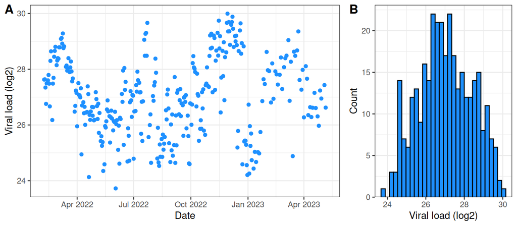

```r
# select one ARA
chosen_ara = "Aarau"
# data management
ww_one = ww1 %>%
  filter(ara_name==chosen_ara) %>%
  # log
  mutate(logvl=log(vl)) %>%
  # duplicate indexes for INLA
  mutate(day1=day) %>%
  mutate(below_loq=as.numeric(as.character(below_loq))) %>%
  rownames_to_column()
# plot
g1 = ggplot(ww_one) +
  geom_point(aes(x=date,y=logvl),colour=cust_cols[1]) +
  labs(x="Date",y="Viral load (log2)")
g2 = ggplot(ww_one) +
  geom_histogram(aes(x=logvl),fill=cust_cols[1],colour="black",bins=30) +
  scale_y_continuous(expand=expansion(c(0,0.05))) +
  labs(x="Viral load (log2)",y="Count")
cowplot::plot_grid(g1,g2,labels=c("A","B"),rel_widths = c(2,1))
```

## Model A1: linear regression

We use gamma regression as the dependent variable is continuous and strictly positive. The log transformation implies that all effects are multiplicative. The first, basic model only includes a exponential trend over time:

$$\log(V_i) = \alpha + \beta t_i$$

We model the limit of quantification by allowing for a larger variability in viral load when the concentration estimate is below the LOQ (note that because of changing flow it may not always correspond to the lowest viral load values):
$$\log(V_i) =
\alpha + \beta t_i + \gamma^{LOQ_i}$$
$$\gamma^{LOQ_i} \sim normal(0,\sigma^{LOQ})$$
Note that the INLA output shows precision, so $1/\gamma^{LOQ_i}$.

```r
ma1 = INLA::inla(vl ~ 1 +
                   f(below_loq,model="iid") +
                   day,
                 data = ww_one,
                 family = "gamma",
                 control.compute = list(waic=TRUE,config=TRUE),
                 control.predictor = list(compute=TRUE,link=1))
summary(ma1)
```

```
##
## Call:
##    c("inla.core(formula = formula, family = family, contrasts = contrasts, ", " data = data, quantiles = quantiles, E = E, offset = offset, ", " scale = scale, weights = weights, Ntrials = Ntrials, strata = strata, ", " lp.scale = lp.scale, link.covariates = link.covariates, verbose = verbose, ",…
##    blas.num.threads = blas.num.threads, keep = keep, working.directory = working.directory, ", " silent = silent, inla.mode = inla.mode, safe = FALSE, debug = debug, ", " .parent.frame = .parent.frame)")
## Time used:
##     Pre = 0.542, Running = 0.193, Post = 0.106, Total = 0.842
## Fixed effects:
##               mean    sd 0.025quant 0.5quant 0.975quant   mode  kld
## (Intercept) 25.854 1.371     23.017   25.883     28.564 25.945 0.01
## day          0.002 0.000      0.001    0.002      0.003  0.002 0.00
##
## Random effects:
##   Name     Model
##     below_loq IID model
##
## Model hyperparameters:
##                                                 mean    sd 0.025quant 0.5quant 0.975quant  mode
## Precision parameter for the Gamma observations 0.776 0.052      0.679    0.775      0.883 0.772
## Precision for below_loq                        0.559 0.554      0.058    0.396      2.033 0.162
##
## Watanabe-Akaike information criterion (WAIC) ...: 19223.79
## Effective number of parameters .................: 3.06
##
## Marginal log-Likelihood:  -9640.63
##  is computed
## Posterior summaries for the linear predictor and the fitted values are computed
## (Posterior marginals needs also 'control.compute=list(return.marginals.predictor=TRUE)')
```

```r
summary_exp_vl(ma1,pars="day")
```

```
##     exp(beta) 0.025quant 0.975quant
## day         1          1          1
```

```r
if(controls$compute_cv) kfoldcv_vl(ww_one,ma1)
```

```
## $RMSE
## [1] 1.925439e+12
##
## $coverage
## [1] 0.08
##
## $logRMSE
## [1] 1.71
##
## $sharpness
## [1] 0.2
```

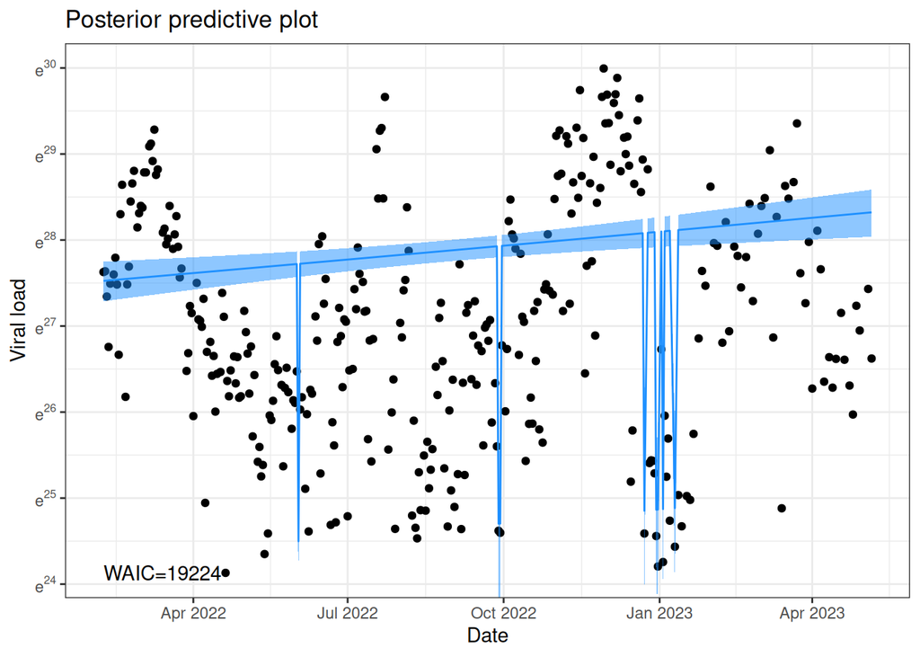

```r
ppp_vl(ww_one,ma1)
```

In the output we can see the call, the used time in seconds, the posterior estimates of the parameters and hyperparameters, and the WAIC. We show the exponential of the fixed parameters that are directly interpretable as multiplicative effects. We also look at the posterior predictive plot comparing the data with model predictions.

## Model A2: random walk

We model the variation in log viral load over time with a random walk, so that the differences between two successive observations follow a normal distribution.

```r
ma2 = INLA::inla(vl ~ 1 +
                   f(below_loq,model="iid") +
                   f(day, model="rw1", scale.model=TRUE, constr=TRUE),
                 data = ww_one,
                 family = "gamma",
                 control.compute = list(waic=TRUE,config=TRUE),
                 control.predictor = list(compute=TRUE,link=1))
summary(ma2)
```

```
##
## Call:
##    c("inla.core(formula = formula, family = family, contrasts = contrasts, ", " data = data, quantiles = quantiles, E = E, offset = offset, ", " scale = scale, weights = weights, Ntrials = Ntrials, strata = strata, ", " lp.scale = lp.scale, link.covariates = link.covariates, verbose = verbose, ",…
##    blas.num.threads = blas.num.threads, keep = keep, working.directory = working.directory, ", " silent = silent, inla.mode = inla.mode, safe = FALSE, debug = debug, ", " .parent.frame = .parent.frame)")
## Time used:
##     Pre = 0.515, Running = 0.527, Post = 0.0513, Total = 1.09
## Fixed effects:
##               mean    sd 0.025quant 0.5quant 0.975quant   mode   kld
## (Intercept) 26.408 0.698     24.881   26.433     27.808 26.474 0.001
##
## Random effects:
##   Name     Model
##     below_loq IID model
##    day RW1 model
##
## Model hyperparameters:
##                                                 mean    sd 0.025quant 0.5quant 0.975quant  mode
## Precision parameter for the Gamma observations 2.564 0.257      2.091    2.552       3.10 2.531
## Precision for below_loq                        2.143 2.352      0.168    1.425       8.46 0.470
## Precision for day                              0.138 0.031      0.087    0.134       0.21 0.127
##
## Watanabe-Akaike information criterion (WAIC) ...: 18825.31
## Effective number of parameters .................: 74.56
##
## Marginal log-Likelihood:  -10160.71
##  is computed
## Posterior summaries for the linear predictor and the fitted values are computed
## (Posterior marginals needs also 'control.compute=list(return.marginals.predictor=TRUE)')
```

```r
if(controls$compute_cv) kfoldcv_vl(ww_one,ma2)
```

```
## $RMSE
## [1] 9.391966e+13
##
## $coverage
## [1] 0.81
##
## $logRMSE
## [1] 2.24
##
## $sharpness
## [1] 2.21
```

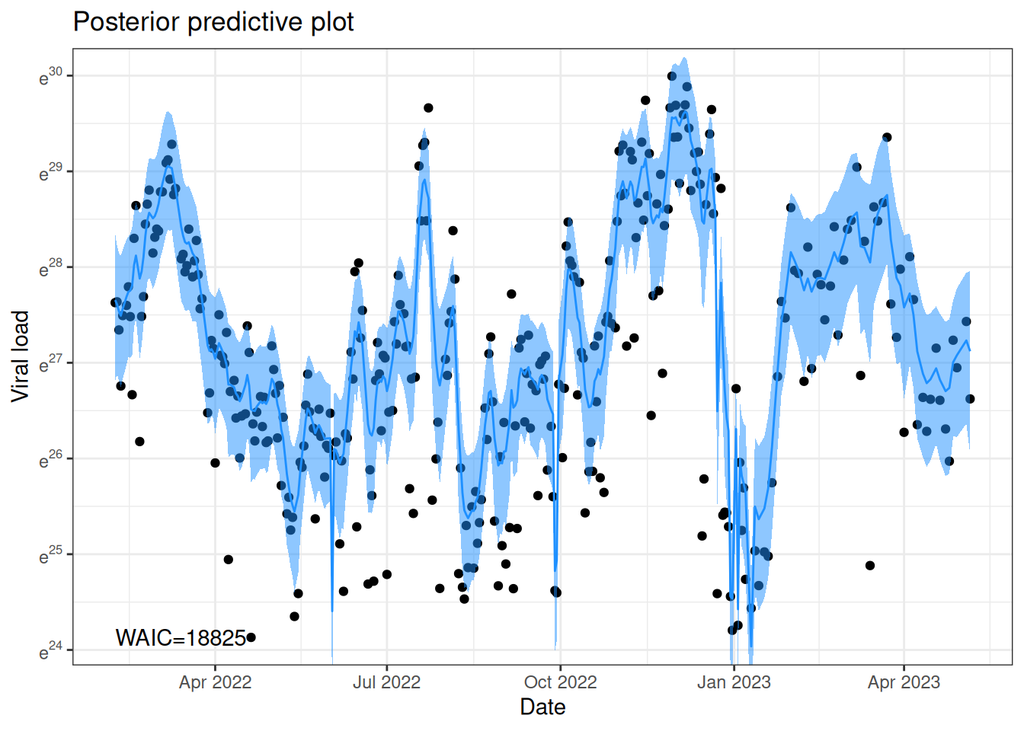

```r
ppp_vl(ww_one,ma2)
```

We see that the model fits much better, although visual inspection indicates over-fitting.

## Model A3: random walk of order 2

We attempt to reduce over-fitting by using a random-walk of order 2, so that the difference depends on the last 2 observations.

```r
ma3 = INLA::inla(vl ~ 1 +
                   f(below_loq,model="iid") +
                   f(day,model="rw2", scale.model=TRUE),
                 data = ww_one,
                 family = "gamma",
                 control.compute = list(waic=TRUE,config=TRUE),
                 control.predictor = list(compute=TRUE,link=1))
summary(ma3)
```

```
##
## Call:
##    c("inla.core(formula = formula, family = family, contrasts = contrasts, ", " data = data, quantiles = quantiles, E = E, offset = offset, ", " scale = scale, weights = weights, Ntrials = Ntrials, strata = strata, ", " lp.scale = lp.scale, link.covariates = link.covariates, verbose = verbose, ",…
##    blas.num.threads = blas.num.threads, keep = keep, working.directory = working.directory, ", " silent = silent, inla.mode = inla.mode, safe = FALSE, debug = debug, ", " .parent.frame = .parent.frame)")
## Time used:
##     Pre = 0.519, Running = 0.246, Post = 0.056, Total = 0.821
## Fixed effects:
##               mean    sd 0.025quant 0.5quant 0.975quant   mode kld
## (Intercept) 26.422 0.754     24.762   26.449     27.941 26.496   0
##
## Random effects:
##   Name     Model
##     below_loq IID model
##    day RW2 model
##
## Model hyperparameters:
##                                                 mean    sd 0.025quant 0.5quant 0.975quant  mode
## Precision parameter for the Gamma observations 1.870 0.156      1.580    1.865      2.194 1.854
## Precision for below_loq                        1.925 2.029      0.157    1.312      7.357 0.441
## Precision for day                              0.005 0.002      0.002    0.004      0.011 0.003
##
## Watanabe-Akaike information criterion (WAIC) ...: 18888.89
## Effective number of parameters .................: 31.60
##
## Marginal log-Likelihood:  -11414.75
##  is computed
## Posterior summaries for the linear predictor and the fitted values are computed
## (Posterior marginals needs also 'control.compute=list(return.marginals.predictor=TRUE)')
```

```r
if(controls$compute_cv) kfoldcv_vl(ww_one,ma3)
```

```
## $RMSE
## [1] 3.649005e+50
##
## $coverage
## [1] 0.75
##
## $logRMSE
## [1] 14.87
##
## $sharpness
## [1] 3.55
```

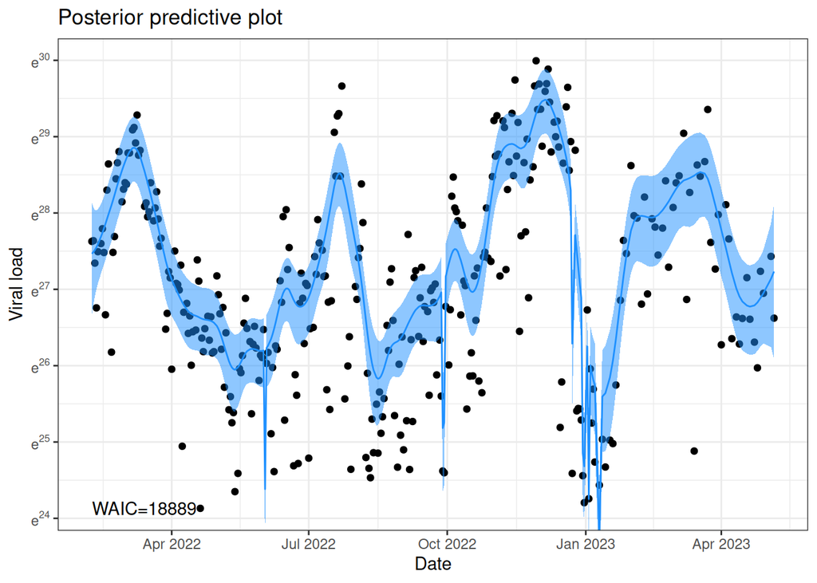

```r
ppp_vl(ww_one,ma3)
```

## Model A4: random walk of order 2 + penalized complexity

We reduce over-fitting by adding priors that penalize complexity (Simpson et al, 2017).

```r
ma4 = INLA::inla(vl ~ 1 +
                   f(below_loq,model="iid") +
                   f(day, model="rw2", scale.model=TRUE, constr=TRUE,
                     hyper=list(prec = list(prior = "pc.prec", param = c(1, 0.01)))),
                 data = ww_one,
                 family = "gamma",
                 control.compute = list(waic=TRUE,config=TRUE),
                 control.predictor = list(compute=TRUE,link=1))
summary(ma4)
```

```
##
## Call:
##    c("inla.core(formula = formula, family = family, contrasts = contrasts, ", " data = data, quantiles = quantiles, E = E, offset = offset, ", " scale = scale, weights = weights, Ntrials = Ntrials, strata = strata, ", " lp.scale = lp.scale, link.covariates = link.covariates, verbose = verbose, ",…
##    blas.num.threads = blas.num.threads, keep = keep, working.directory = working.directory, ", " silent = silent, inla.mode = inla.mode, safe = FALSE, debug = debug, ", " .parent.frame = .parent.frame)")
## Time used:
##     Pre = 0.539, Running = 0.252, Post = 0.0527, Total = 0.843
## Fixed effects:
##               mean    sd 0.025quant 0.5quant 0.975quant   mode kld
## (Intercept) 26.211 0.962      24.14   26.232     28.181 26.269   0
##
## Random effects:
##   Name     Model
##     below_loq IID model
##    day RW2 model
##
## Model hyperparameters:
##                                                 mean    sd 0.025quant 0.5quant 0.975quant  mode
## Precision parameter for the Gamma observations 1.582 0.125      1.347    1.578      1.841 1.571
## Precision for below_loq                        1.069 1.062      0.117    0.758      3.883 0.323
## Precision for day                              0.048 0.017      0.024    0.045      0.089 0.040
##
## Watanabe-Akaike information criterion (WAIC) ...: 18940.46
## Effective number of parameters .................: 19.51
##
## Marginal log-Likelihood:  -11433.58
##  is computed
## Posterior summaries for the linear predictor and the fitted values are computed
## (Posterior marginals needs also 'control.compute=list(return.marginals.predictor=TRUE)')
```

```r
if(controls$compute_cv) kfoldcv_vl(ww_one,ma4)
```

```
## $RMSE
## [1] 9.81558e+20
##
## $coverage
## [1] 0.57
##
## $logRMSE
## [1] 3.87
##
## $sharpness
## [1] 1.41
```

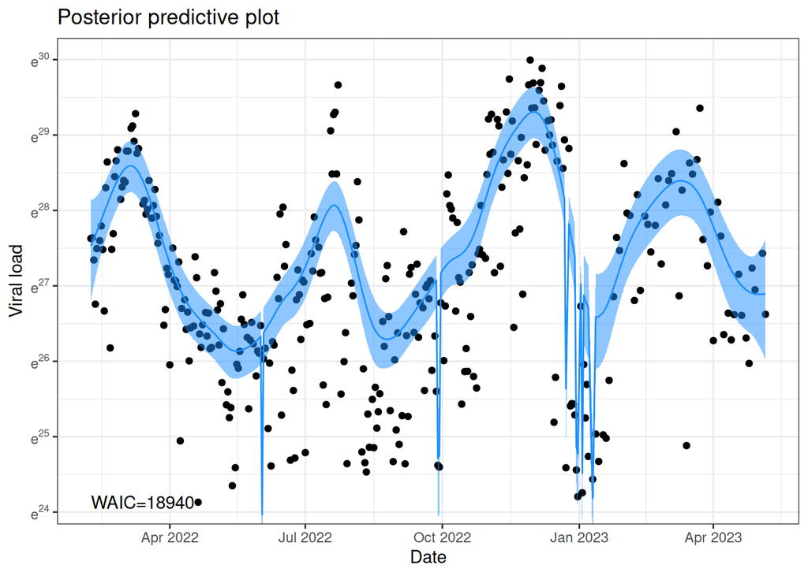

```r
ppp_vl(ww_one,ma4)
```

The model now appropriately captures the dynamics of SARS-CoV-2 viral load, although still underestimates the variability especially during certain periods.

## Model A5: additional covariates

There are other covariates available at the level of an ARA that may explain part of the residual variability. One is a change in the methods used to quantify SARS-CoV-2. A second is the day of the week, as behaviour may change for instance during weekends. For fixed effects we use weak normal priors with mean 0 and variance 5 on the log scale, corresponding to relative viral load values ranging between 0.01 and 80 (95% CrI).

```r
ma5 = INLA::inla(vl ~ 1 +
                   f(below_loq,model="iid",constr=FALSE) +
                   f(day,model="rw2", scale.model=TRUE, constr=TRUE,
                     hyper=list(prec = list(prior = "pc.prec", param = c(1, 0.01)))) +
                   f(method,model="linear",mean.linear=0,prec.linear=.2) +
                   f(weekend,model="linear",mean.linear=0,prec.linear=.2) +
                   f(hol,model="linear",mean.linear=0,prec.linear=.2),
                 data = ww_one,
                 family = "gamma",
                 control.compute = list(waic=TRUE,config=TRUE),
                 control.predictor = list(compute=TRUE,link=1))
summary(ma5)
```

```
##
## Call:
##    c("inla.core(formula = formula, family = family, contrasts = contrasts, ", " data = data, quantiles = quantiles, E = E, offset = offset, ", " scale = scale, weights = weights, Ntrials = Ntrials, strata = strata, ", " lp.scale = lp.scale, link.covariates = link.covariates, verbose = verbose, ",…
##    blas.num.threads = blas.num.threads, keep = keep, working.directory = working.directory, ", " silent = silent, inla.mode = inla.mode, safe = FALSE, debug = debug, ", " .parent.frame = .parent.frame)")
## Time used:
##     Pre = 0.666, Running = 0.448, Post = 0.0911, Total = 1.21
## Fixed effects:
##               mean    sd 0.025quant 0.5quant 0.975quant   mode kld
## (Intercept) 25.846 1.013     23.677   25.868     27.916 25.906   0
## method       1.187 0.477      0.251    1.187      2.122  1.188   0
## weekend     -0.140 0.092     -0.321   -0.140      0.042 -0.140   0
## hol          0.428 0.229     -0.022    0.428      0.877  0.428   0
##
## Random effects:
##   Name     Model
##     below_loq IID model
##    day RW2 model
##
## Model hyperparameters:
##                                                 mean    sd 0.025quant 0.5quant 0.975quant  mode
## Precision parameter for the Gamma observations 1.629 0.129      1.384    1.626       1.89 1.624
## Precision for below_loq                        1.066 1.264      0.106    0.687       4.35 0.280
## Precision for day                              0.048 0.017      0.025    0.045       0.09 0.039
##
## Watanabe-Akaike information criterion (WAIC) ...: 18932.12
## Effective number of parameters .................: 21.70
##
## Marginal log-Likelihood:  -11434.16
##  is computed
## Posterior summaries for the linear predictor and the fitted values are computed
## (Posterior marginals needs also 'control.compute=list(return.marginals.predictor=TRUE)')
```

```r
summary_exp_vl(ma5,pars = "method|weekend|hol|test")
```

```
##         exp(beta) 0.025quant 0.975quant
## method       3.28       1.29       8.34
## weekend      0.87       0.73       1.04
## hol          1.53       0.98       2.40
```

```r
if(controls$compute_cv) kfoldcv_vl(ww_one,ma5)
```

```
## $RMSE
## [1] 7.597832e+20
##
## $coverage
## [1] 0.57
##
## $logRMSE
## [1] 3.85
##
## $sharpness
## [1] 1.45
```

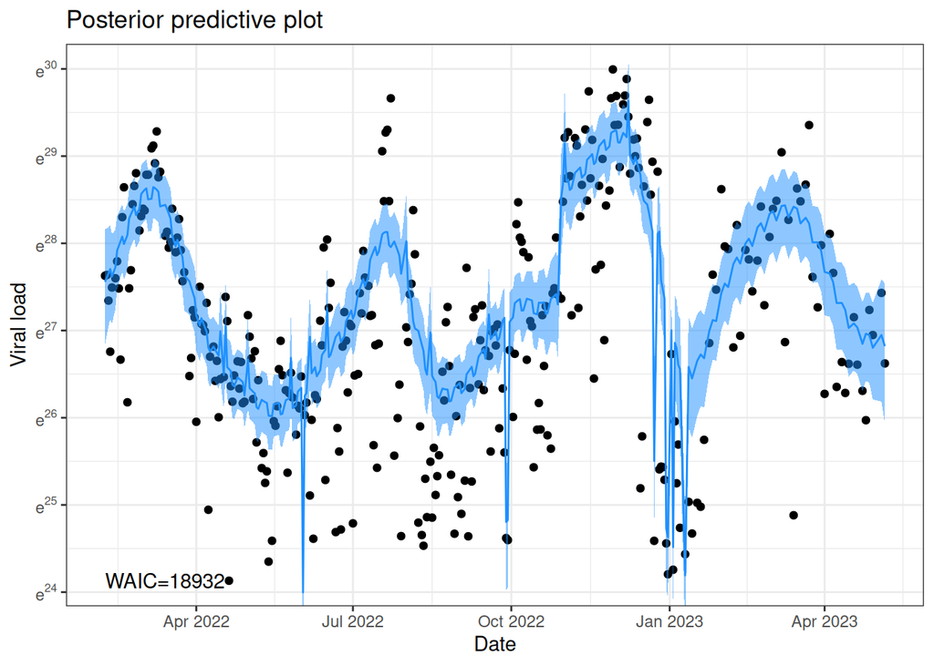

```r
ppp_vl(ww_one,ma5)
```

### Model A5 on Basel

We apply model A5 to the Basel ARA, and even though there is no change in method the model fits quite well.

```r
chosen_ara = "Basel"
ww_one = ww1 %>%
  filter(ara_name==chosen_ara) %>%
  # log
  mutate(logvl=log(vl)) %>%
  # duplicate indexes for INLA
  mutate(day1=day) %>%
  rownames_to_column()
ma5b = INLA::inla(vl ~ 1 +
                    f(below_loq, model="iid") +
                    f(day,model="rw2", scale.model=TRUE, constr=TRUE,
                      hyper=list(prec = list(prior = "pc.prec", param = c(1, 0.01)))) +
                    f(method,model="linear",mean.linear=0,prec.linear=.2) +
                    f(weekend,model="linear",mean.linear=0,prec.linear=.2) +
                    f(hol,model="linear",mean.linear=0,prec.linear=.2),
                  data = ww_one,
                  family = "gamma",
                  control.compute = list(waic=TRUE,config=TRUE),
                  control.predictor = list(compute=TRUE,link=1))
summary(ma5b)
```

```
##
## Call:
##    c("inla.core(formula = formula, family = family, contrasts = contrasts, ", " data = data, quantiles = quantiles, E = E, offset = offset, ", " scale = scale, weights = weights, Ntrials = Ntrials, strata = strata, ", " lp.scale = lp.scale, link.covariates = link.covariates, verbose = verbose, ",…
##    blas.num.threads = blas.num.threads, keep = keep, working.directory = working.directory, ", " silent = silent, inla.mode = inla.mode, safe = FALSE, debug = debug, ", " .parent.frame = .parent.frame)")
## Time used:
##     Pre = 0.475, Running = 0.296, Post = 0.0832, Total = 0.854
## Fixed effects:
##               mean    sd 0.025quant 0.5quant 0.975quant   mode kld
## (Intercept) 30.014 0.040     29.935   30.013     30.093 30.013   0
## method       0.000 2.236     -4.385    0.000      4.385  0.000   0
## weekend     -0.015 0.057     -0.127   -0.015      0.098 -0.015   0
## hol          0.079 0.193     -0.300    0.079      0.457  0.079   0
##
## Random effects:
##   Name     Model
##     below_loq IID model
##    day RW2 model
##
## Model hyperparameters:
##                                                    mean       sd 0.025quant 0.5quant 0.975quant     mode
## Precision parameter for the Gamma observations 3.33e+00 2.65e-01      2.834 3.32e+00   3.88e+00    3.303
## Precision for below_loq                        1.66e+04 1.63e+04   1097.829 1.17e+04   6.01e+04 3015.913
## Precision for day                              2.30e-02 6.00e-03      0.013 2.30e-02   3.80e-02    0.021
##
## Watanabe-Akaike information criterion (WAIC) ...: 23570.95
## Effective number of parameters .................: 38.33
##
## Marginal log-Likelihood:  -14152.84
##  is computed
## Posterior summaries for the linear predictor and the fitted values are computed
## (Posterior marginals needs also 'control.compute=list(return.marginals.predictor=TRUE)')
```

```r
summary_exp_vl(ma5b,pars = "method|weekend|hol")
```

```
##         exp(beta) 0.025quant 0.975quant
## method       1.00       0.01      80.26
## weekend      0.99       0.88       1.10
## hol          1.08       0.74       1.58
```

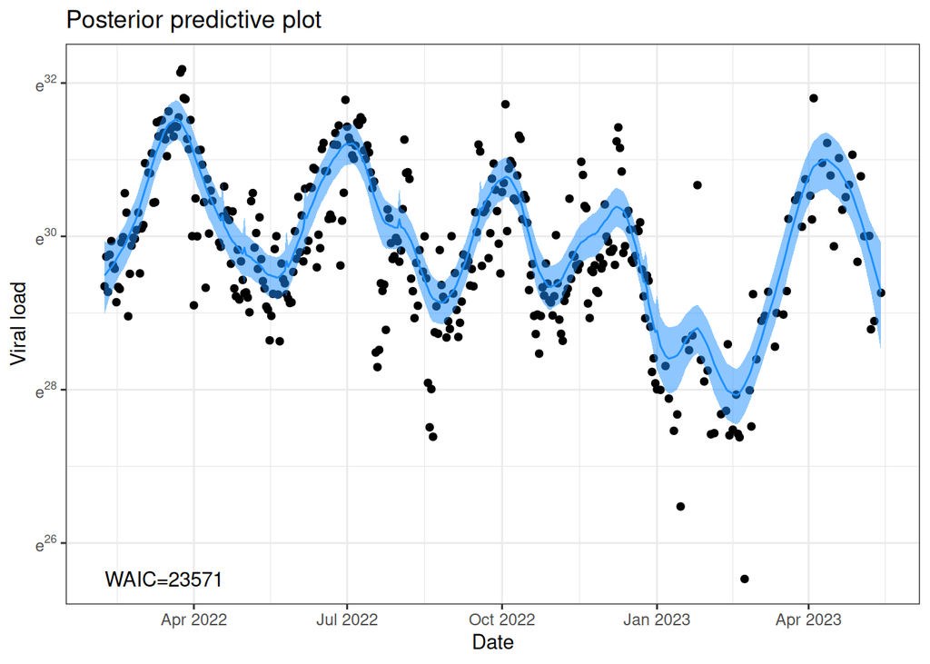

```r
ppp_vl(ww_one,ma5b)
```

### Model A5 on Region Bern

Contrary to Aarau, we find measurements of zero in Region Bern, which creates problems with logarithms. Instead of using zero-inflated models, we treat the zero values as very low (value = 1) and allow for additional variability, similarly to values below the limit of detection.

```r
chosen_ara = "Region Bern"
# data management
ww_one = ww1 %>%
  filter(ara_name==chosen_ara) %>%
  # log
  mutate(logvl=log(vl)) %>%
  mutate(vl=if_else(vl==0, 1, vl)) %>%
  # mutate(below_loq=if_else(below_lod==1,below_lod,below_loq)) %>%
  # duplicate indexes for INLA
  mutate(day1=day) %>%
  rownames_to_column()
ma5b = INLA::inla(vl ~ 1 +
                    f(below_loq,model="iid") +
                    f(below_lod,model="iid") +
                   f(day,model="rw2", scale.model=TRUE, constr=TRUE,
                     hyper=list(prec = list(prior = "pc.prec", param = c(1, 0.01)))) +
                    f(method,model="linear",mean.linear=0,prec.linear=.2) +
                    f(weekend,model="linear",mean.linear=0,prec.linear=.2) +
                    f(hol,model="linear",mean.linear=0,prec.linear=.2),
                 data = ww_one,
                 family = "gamma",
                 control.compute = list(waic=TRUE,config=TRUE),
                 control.predictor = list(compute=TRUE,link=1))
summary(ma5b)
```

```
##
## Call:
##    c("inla.core(formula = formula, family = family, contrasts = contrasts, ", " data = data, quantiles = quantiles, E = E, offset = offset, ", " scale = scale, weights = weights, Ntrials = Ntrials, strata = strata, ", " lp.scale = lp.scale, link.covariates = link.covariates, verbose = verbose, ",…
##    blas.num.threads = blas.num.threads, keep = keep, working.directory = working.directory, ", " silent = silent, inla.mode = inla.mode, safe = FALSE, debug = debug, ", " .parent.frame = .parent.frame)")
## Time used:
##     Pre = 0.48, Running = 0.313, Post = 0.125, Total = 0.918
## Fixed effects:
##               mean     sd 0.025quant 0.5quant 0.975quant   mode   kld
## (Intercept) 14.327 10.145     -6.904   14.329     35.549 14.332 0.001
## method       0.000  2.236     -4.385    0.000      4.385  0.000 0.000
## weekend     -0.134  0.111     -0.352   -0.134      0.084 -0.134 0.000
## hol          0.184  0.312     -0.430    0.184      0.796  0.184 0.000
##
## Random effects:
##   Name     Model
##     below_loq IID model
##    below_lod IID model
##    day RW2 model
##
## Model hyperparameters:
##                                                    mean       sd 0.025quant 0.5quant 0.975quant     mode
## Precision parameter for the Gamma observations 1.85e+00 1.57e-01      1.551 1.84e+00   2.17e+00    1.835
## Precision for below_loq                        1.86e+04 1.83e+04   1256.459 1.31e+04   6.73e+04 3452.175
## Precision for below_lod                        7.00e-03 6.00e-03      0.001 6.00e-03   2.30e-02    0.003
## Precision for day                              2.49e-01 1.28e-01      0.091 2.20e-01   5.78e-01    0.174
##
## Watanabe-Akaike information criterion (WAIC) ...: 15684.87
## Effective number of parameters .................: 20.30
##
## Marginal log-Likelihood:  -9411.52
##  is computed
## Posterior summaries for the linear predictor and the fitted values are computed
## (Posterior marginals needs also 'control.compute=list(return.marginals.predictor=TRUE)')
```

```r
summary_exp_vl(ma5b,pars = "method|weekend|hol")
```

```
##         exp(beta) 0.025quant 0.975quant
## method       1.00       0.01      80.26
## weekend      0.87       0.70       1.09
## hol          1.20       0.65       2.22
```

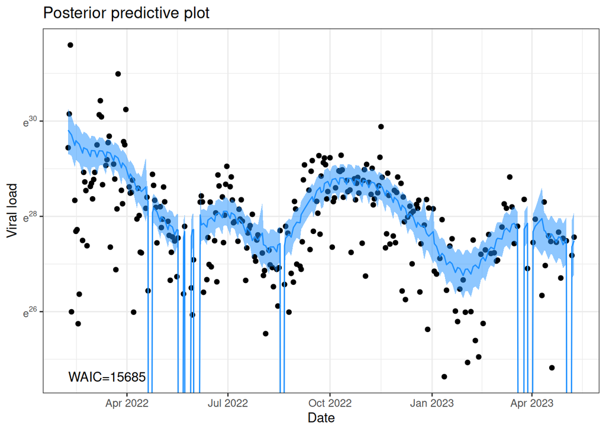

```r
ppp_vl(ww_one,ma5b)
```

### Model A5 on Saanen

Saanen is the place with the most number of measurements below the limit of detection.

```r
chosen_ara = "Saanen"
# data management
ww_one = ww1 %>%
  filter(ara_name==chosen_ara) %>%
  # log
  filter(!is.na(vl)) %>%
  mutate(logvl=log(vl)) %>%
  mutate(vl=if_else(vl==0, 1, vl)) %>%
  mutate(below_loq=if_else(below_lod==1,below_lod,below_loq)) %>%
  # duplicate indexes for INLA
  mutate(day1=day) %>%
  rownames_to_column()
ma5b = INLA::inla(vl ~ 1 +
                    f(below_loq,model="iid") +
                    f(below_lod,model="iid") +
                    f(day,model="rw2", scale.model=TRUE, constr=TRUE,
                      hyper=list(prec = list(prior = "pc.prec", param = c(1, 0.01)))) +
                    f(method,model="linear",mean.linear=0,prec.linear=.2) +
                    f(weekend,model="linear",mean.linear=0,prec.linear=.2) +
                    f(hol,model="linear",mean.linear=0,prec.linear=.2),
                  data = ww_one,
                  family = "gamma",
                  control.compute = list(waic=TRUE,config=TRUE),
                  control.predictor = list(compute=TRUE,link=1))
summary(ma5b)
```

```
##
## Call:
##    c("inla.core(formula = formula, family = family, contrasts = contrasts, ", " data = data, quantiles = quantiles, E = E, offset = offset, ", " scale = scale, weights = weights, Ntrials = Ntrials, strata = strata, ", " lp.scale = lp.scale, link.covariates = link.covariates, verbose = verbose, ",…
##    blas.num.threads = blas.num.threads, keep = keep, working.directory = working.directory, ", " silent = silent, inla.mode = inla.mode, safe = FALSE, debug = debug, ", " .parent.frame = .parent.frame)")
## Time used:
##     Pre = 0.626, Running = 0.509, Post = 0.112, Total = 1.25
## Fixed effects:
##               mean     sd 0.025quant 0.5quant 0.975quant   mode   kld
## (Intercept) 14.651 13.501    -12.013   14.653     41.312 14.661 0.001
## method       0.000  2.236     -4.385    0.000      4.385  0.000 0.000
## weekend      0.149  0.123     -0.093    0.149      0.392  0.148 0.000
## hol          0.063  0.365     -0.653    0.063      0.778  0.064 0.000
##
## Random effects:
##   Name     Model
##     below_loq IID model
##    below_lod IID model
##    day RW2 model
##
## Model hyperparameters:
##                                                    mean       sd 0.025quant 0.5quant 0.975quant     mode
## Precision parameter for the Gamma observations     1.80 1.94e-01      1.474    1.780   2.24e+00    1.725
## Precision for below_loq                        16432.35 4.00e+04    582.909 6479.033   9.58e+04 1421.620
## Precision for below_lod                            0.01 2.60e-02      0.000    0.004   5.80e-02    0.001
## Precision for day                                  0.71 5.23e-01      0.167    0.570   2.10e+00    0.377
##
## Watanabe-Akaike information criterion (WAIC) ...: 7610.14
## Effective number of parameters .................: 13.43
##
## Marginal log-Likelihood:  -4507.45
##  is computed
## Posterior summaries for the linear predictor and the fitted values are computed
## (Posterior marginals needs also 'control.compute=list(return.marginals.predictor=TRUE)')
```

```r
summary_exp_vl(ma5b,pars = "method|weekend|hol")
```

```
##         exp(beta) 0.025quant 0.975quant
## method       1.00       0.01      80.26
## weekend      1.16       0.91       1.48
## hol          1.07       0.52       2.18
```

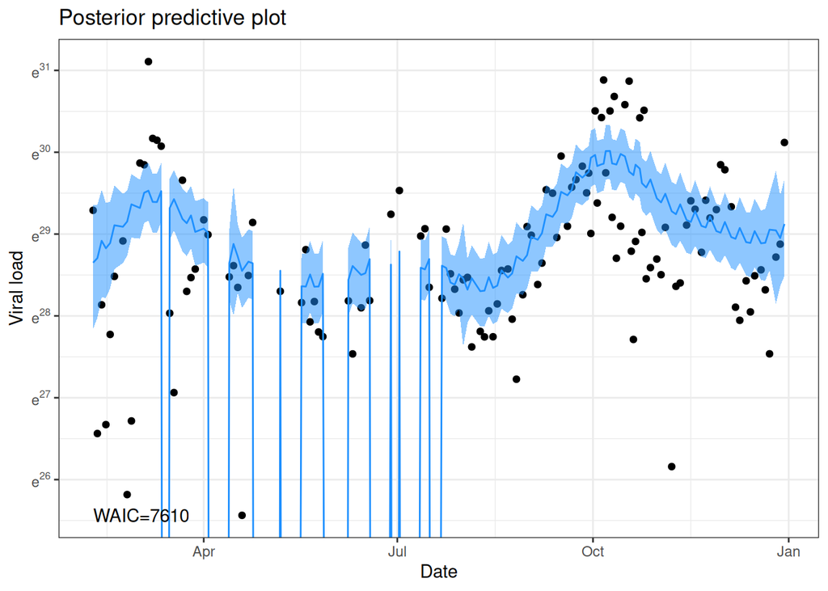

```r
ppp_vl(ww_one,ma5b)
```

### Model A5 on Laupen

In Laupen there are many measurements below the limit of quantification, the model is still fine.

```r
chosen_ara = "Laupen"
# data management
ww_one = ww1 %>%
  filter(ara_name==chosen_ara) %>%
  # log
  mutate(logvl=log(vl)) %>%
  mutate(vl=if_else(vl==0, 1, vl)) %>%
  # duplicate indexes for INLA
  mutate(day1=day) %>%
  rownames_to_column()
ma5b = INLA::inla(vl ~ 1 +
                    f(below_loq,model="iid") +
                    f(below_lod,model="iid") +
                    f(day,model="rw2", scale.model=TRUE, constr=TRUE,
                      hyper=list(prec = list(prior = "pc.prec", param = c(1, 0.01)))) +
                    f(method,model="linear",mean.linear=0,prec.linear=.2) +
                    f(weekend,model="linear",mean.linear=0,prec.linear=.2) +
                    f(hol,model="linear",mean.linear=0,prec.linear=.2),
                  data = ww_one,
                  family = "gamma",
                  control.compute = list(waic=TRUE,config=TRUE),
                  control.predictor = list(compute=TRUE,link=1))
summary(ma5b)
```

```
##
## Call:
##    c("inla.core(formula = formula, family = family, contrasts = contrasts, ", " data = data, quantiles = quantiles, E = E, offset = offset, ", " scale = scale, weights = weights, Ntrials = Ntrials, strata = strata, ", " lp.scale = lp.scale, link.covariates = link.covariates, verbose = verbose, ",…
##    blas.num.threads = blas.num.threads, keep = keep, working.directory = working.directory, ", " silent = silent, inla.mode = inla.mode, safe = FALSE, debug = debug, ", " .parent.frame = .parent.frame)")
## Time used:
##     Pre = 0.465, Running = 0.62, Post = 0.126, Total = 1.21
## Fixed effects:
##               mean    sd 0.025quant 0.5quant 0.975quant   mode   kld
## (Intercept) 28.801 0.219     28.318   28.810     29.240 28.824 0.001
## method       0.000 2.236     -4.385    0.000      4.385  0.000 0.000
## weekend      0.042 0.043     -0.042    0.042      0.126  0.042 0.000
## hol         -0.075 0.142     -0.353   -0.075      0.204 -0.075 0.000
##
## Random effects:
##   Name     Model
##     below_loq IID model
##    below_lod IID model
##    day RW2 model
##
## Model hyperparameters:
##                                                    mean       sd 0.025quant 0.5quant 0.975quant     mode
## Precision parameter for the Gamma observations 5.11e+00 3.54e-01      4.459    5.087   5.85e+00    5.040
## Precision for below_loq                        2.41e+01 2.56e+01      1.862   16.372   9.21e+01    5.168
## Precision for below_lod                        1.33e+04 1.36e+04    832.580 9041.544   5.00e+04 2270.223
## Precision for day                              9.90e-02 3.00e-02      0.055    0.094   1.71e-01    0.084
##
## Watanabe-Akaike information criterion (WAIC) ...: 26464.83
## Effective number of parameters .................: 24.95
##
## Marginal log-Likelihood:  -15970.78
##  is computed
## Posterior summaries for the linear predictor and the fitted values are computed
## (Posterior marginals needs also 'control.compute=list(return.marginals.predictor=TRUE)')
```

```r
summary_exp_vl(ma5b,pars = "method|weekend|hol")
```

```
##         exp(beta) 0.025quant 0.975quant
## method       1.00       0.01      80.26
## weekend      1.04       0.96       1.13
## hol          0.93       0.70       1.23
```

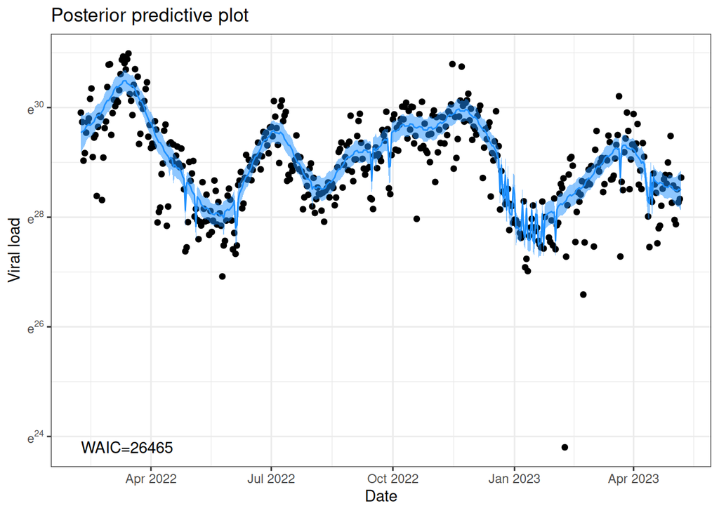

```r
ppp_vl(ww_one,ma5b)
```